# SymPy 2022 Documentation Theme Survey Analysis

# Methodology

SymPy ran a user survey about its documentation theme from February 5-19, 2022. The primary purpose of the survey was to guide the selection of a Sphinx theme for the SymPy Documentation at https://docs.sympy.org.

A total of 22 people responded. The survey was done on Google Surveys and was shared on the SymPy public mailing list, the [@SymPy](https://twitter.com/SymPy) Twitter account, and a [SymPy discussion on GitHub](https://github.com/sympy/sympy/discussions/23055). The survey consisted of 14 questions, all of which were optional. The results of these responses are summarized here. We would like to thank everyone who took and shared the survey.

Four themes were [chosen based on factors such as layout, navigation, performance, and accessibility](https://github.com/sympy/sympy/issues/22716) for evaluation by the SymPy community. Each theme was "prototyped" by

- Applying the theme to the SymPy dev documentation
- Removing SymPy Live, which has several problems, is [planned to be removed in the live documentation](https://github.com/sympy/sympy/issues/22835), and affects the formatting of the documentation site due to importing a style sheet
- [Hosting them on GitHub Pages](https://bertiewooster.github.io/sympy-doc/)

No attempt was made to customize the four themes because that is anticipated to be a time-consuming process with both technical (styling) and consensus-building components. Respondents were thus encouraged to focus on the layout, navigation, and interactive features, rather than the exact styling, for example colors.

For each of the four themes, respondents were asked to

- Rate the theme's usefulness of a scale of 1 (Not very useful) to 4 (Very useful)
- Share what they liked and disliked

# Summary

A detailed analysis of the responses is provided below. At a high level, there are three main takeaways from the results.

1. The themes can be divided into three ratings categories, where the rating scale was 1 (Not very useful) to 4 (Very useful):
   1. Highest: Furo at 2.95.
   2. Middle: PyData and Book, nearly tied at 2.85 and 2.86, respectively.
   3. Lowest: Read the Docs (RTD) at 2.47.
2. Most comments about themes, both likes and dislikes, were about formatting, look and feel, and navigation.
3. We should proceed with the Furo theme, customizing it to address respondents' dislikes about its formatting. We can keep the PyData and Book themes in mind as backup options.

## Experience Level

The first question asked the respondents to place their SymPy experience level on a scale of 1 to 5, with 1 being "novice user" and 5 being "expert user".

Most respondents self-reported a mid-level experience with SymPy.

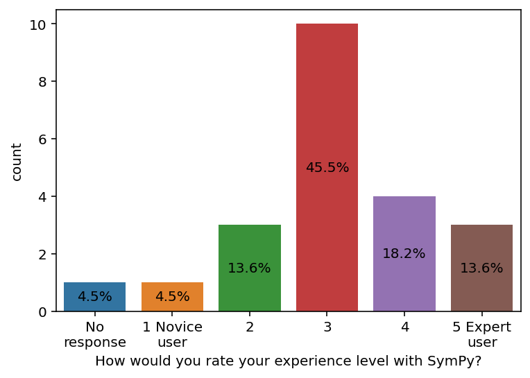

## Theme Ratings

The survey asked respondents to rate the usefulness of four themes on a 1-4 scale, with 1 being Not very useful and 4 being Very useful. The mean and standard deviation of the rating for each theme are expressed numerically and graphically as:

|  | mean | std |
| --- | --- | --- |
| How useful is the PyData theme? | 2.85 | 0.75 |
| How useful is the Book theme? | 2.86 | 0.79 |
| How useful is the Furo theme? | 2.95 | 1.02 |
| How useful is the Read the Docs (RTD) theme? | 2.47 | 0.90 |

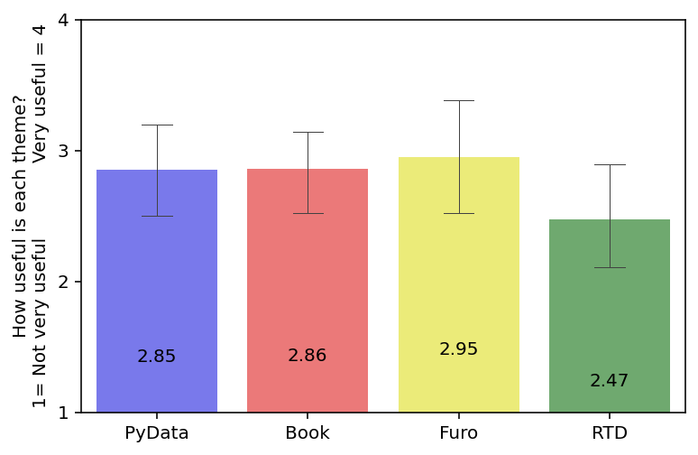

Furo is the highest-rated theme by about 0.1 points. PyData and Book are virtually tied for second place. Read the Docs is rated lowest, about 0.5 points below Furo.

## Rating Distribution for Themes

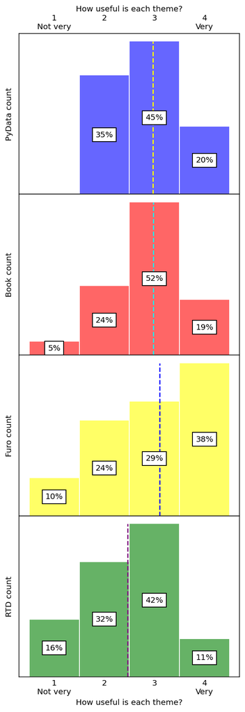

For Furo, the mode is 4, Very useful. The mode of the other three themes is 3.

# Furo theme

Given that Furo is the highest-rated theme, it is worth considering other factors before deciding to proceed with it.

## Comments about Furo

Here are consolidated lists of highlights from what respondents liked and disliked about Furo.

- Like
  - Clean look and clear font
  - Left and right sidebars for site and page navigation, respectively
  - Has both light and dark themes, and is easy to switch between them
  - Dislike
  - Colors are distracting (for example, behind code blocks), too dark without enough contrast
  - Bold and highlighting seem a little cartoonish
  - Not more widely used in documentation for data science packages
  - Collapse of in-page navigation not optimal

## Other factors

- Furo SymPy prototype gets excellent Lighthouse scores before any customization:
  - Performance: 100
  - Accessibility: 98
  - Best Practices: 100
  - SEO (search engine optimization): 90
- Furo is well supported, having frequent updates
- Furo's developer is very accessible, even [commenting on a SymPy thread](https://github.com/sympy/sympy/issues/22716#issuecomment-1013016667) without our asking them
- ["Pretty much every color on the screen is customizable"](https://pradyunsg.me/furo/customisation/colors/#defining-overrides-for-defaults) per Furo's developer so we should be able to address what respondents disliked about colors
- Furo is the only theme that shows a fully expanded table of contents on the right sidebar
- Furo was recommended by Joannah Nanjekye, who spent much time working on the documentation for [2021 Google Season of Docs](https://github.com/sympy/sympy/wiki/GSoD-2021-Report-Joannah-Nanjekye:-Reorganizing-the-SymPy-Documentation)

# Recommendation

For the above reasons, we should proceed with Furo as the new Sphinx theme. Customizing the theme should address some of the deficits of the prototype, such as colors.

Should there be some unexpected reason we cannot customize Furo as desired, we could try PyData or Book.

# Other comments from respondents

Finally, nine people responded to "Are there any other comments you'd like to make?". Here is a summary of some things that stood out.

- All four options are good.
- Whichever theme you go with it’ll be an improvement.
- Please use that nice dark mode

# Appendix: All comments from respondents

For the sake of completeness, all comments are shown below.

```
--- What do you LIKE about the PyData theme? ---
1. search easy to find, updating position in doc on right (experience level: 5)

2. It is a neat theme (experience level: 4)

3. Clear, succint, very little clutter (experience level: 5)

4. I like the clean layout. (experience level: 4)

5. It is neat and simple, with left and right sidebars proving useful. The top sidebar is also quite convenient since scrolling on the left sidebar would be reduced as opposed to themes which lack the top sidebar. (experience level: 3)

6. clear view without distractions (experience level: 2)

7. Flat design, style uniformity accros sur the data exosystem, maintainability of a shared product (experience level: N/A)

8. The docstring rendering is easier to read than the old docs page. Better colors and less clutter. Fits on screen better. (experience level: 3)

9. Readable, not a huge shift (experience level: 3)

10. Desktop: Clean look. The categories across the top. The search box in a fixed position on the left navbar. Good highlighting format (for ?highlight=xxx in URL). Good differentiation between regular text, links (bold, blue), and code (pink). Good permalink setup: ¶ appears when link text moused o…

11. It's very clean looking. Easy to navigate. (experience level: 3)

12. It looks neat and has a floating content menu. (experience level: 5)

13. Reminds me of scipy (experience level: 4)

14. it's clean (experience level: 4)

--- What do you DISLIKE about the PyData theme? ---
1. Looks kinda incomplete (experience level: 4)

2. 3 levels of nesting (top, left, right) was not instantly obvious for how to use. (experience level: 5)

3. I am bothered by the way useful links switch from side-to-side. I do understand the the links at right are to anchors on the particular page. However, sometimes having links on one side, but not the other did not seem natural and was initially confusing. (experience level: 4)

4. Left sidebar occupies a lot of space on the screen. (experience level: 3)

5. nothing (experience level: 2)

```

[output cut: 172 more lines]

```

3. Book is cleaner looking and allows the viewer more adaptations of the display. However, it is likely to be less familiar and a little harder to navigate than rtd for most people. I think either would be acceptable. Book seems a little more 'modern'. The 'modernity' will probably only last for a c…

4. All four options are good. (experience level: 1)

5. thank you for your work on SymPy. (experience level: 2)

6. Whichever theme you go with it’ll be an improvement. Thank you for taking the time to implement this and to ask for feedback ! (experience level: N/A)

7. The first 3 all look the same and have poorly designed menus that don't function as expected. It also seems that there are two menus on some, which is confusing. The last one RTD is really the only one that looks functional to me. (experience level: 3)

8. Please use that nice dark mode (experience level: 3)

9. PyData, Book, and Furo would all be good choices.
Category names (SymPy Tutorial, SymPy Guides, Explanation, Reference Documentation, Miscellaneous) should be shortened, for example remove "SymPy", change "Reference Documentation" to API(?). (experience level: 3)
```